# DATA 608: HW 1

## Question 1

Create a graph that shows the distribution of companies in the dataset by State (i.e. how many are in each state). There are a lot of States, so consider which axis you should use. This visualization is ultimately going to be consumed on a ‘portrait’ oriented screen (ie taller than wide), which should further guide your layout choices.

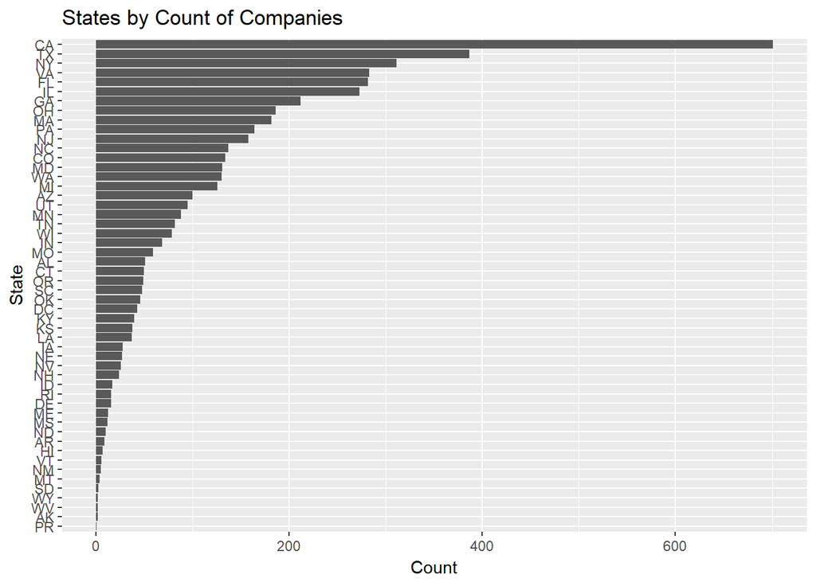

```r
library(ggplot2)

#bar plot
qplot(data=inc, x=reorder(State, table(inc$State)[State]), ylab = "Count", xlab = "State", main = "States by Count of Companies") + geom_bar() + coord_flip()
```

## Question 2

Lets dig in on the state with the 3rd most companies in the data set. Imagine you work for the state and are interested in how many people are employed by companies in different industries. Create a plot that shows the average and/or median employment by industry for companies in this state (only use cases with full data, use R’s `complete.cases()` function.) In addition to this, your graph should show how variable the ranges are, and you should deal with outliers.

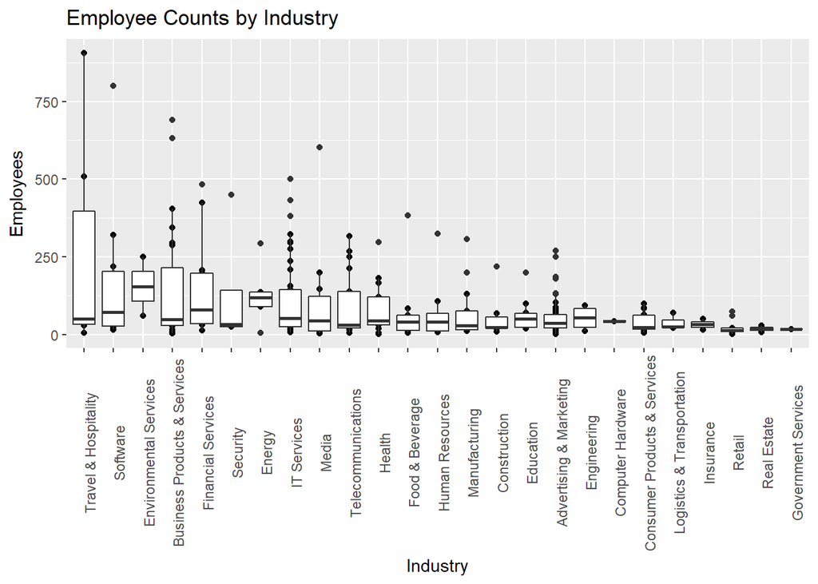

```r
# state with 3rd most companies is: NY
NewYork <- inc %>%
  filter(State=="NY") %>%
  filter(Employees < 1000) #handle outliers based on visual inspection

#complete.cases
NewYork <- NewYork[complete.cases(NewYork),]

#boxplot: handles outliers, ranges, median
qplot(data=NewYork, x=reorder(Industry, -Employees), y=Employees, xlab="Industry", ylab="Employees", main="Employee Counts by Industry") + geom_boxplot() + theme(axis.text.x = element_text(angle=90, vjust=1))
```

## Question 3

Now imagine you work for an investor and want to see which industries generate the most revenue per employee. Create a chart that makes this information clear. Once again, the distribution per industry should be shown.

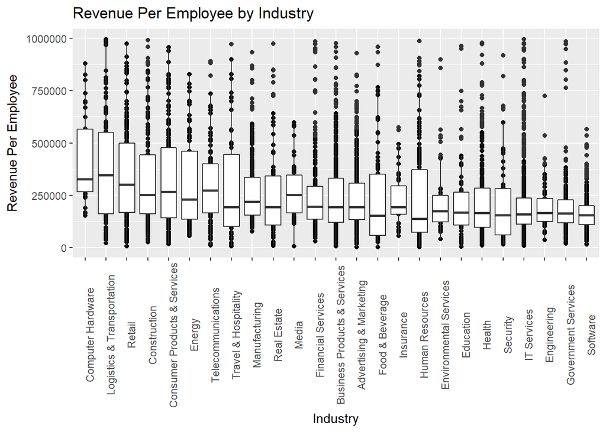

```r
#revenue per employee
inc$RevPerEmp <- inc$Revenue / inc$Employees

#complete cases and remove outliers
inc_complete <-inc[complete.cases(inc),]
inc_complete <- inc %>% filter(RevPerEmp < 1000000)

#boxplot: handles outliers, ranges, median
qplot(data=inc_complete, x=reorder(Industry, -RevPerEmp), y=RevPerEmp, xlab="Industry", ylab="Revenue Per Employee", main="Revenue Per Employee by Industry") + geom_boxplot() + theme(axis.text.x = element_text(angle=90, vjust=1))
```